# The overall workflow in 'Breast_Cancer_EDA'

## 1. The Dataset

## 2. Missing Data Exploration

## 3. Initial Data Cleaning - Remove irrelevant features

## 4. Exploratory Data Analysis

## 5. Next steps

# Packages

```python
# Data structures
import pandas as pd

# Visualizations
import matplotlib.pyplot as plt
plt.style.use("ggplot")
from Breast_Cancer_Functions import relationship_pairplot
```

# 1. The Dataset

- Link: https://www.kaggle.com/uciml/breast-cancer-wisconsin-data

```python
data = pd.read_csv('data.csv')
data.head()
```

|  | id | diagnosis | radius_mean | texture_mean | perimeter_mean | area_mean | smoothness_mean | compactness_mean | concavity_mean | concave points_mean | ... | texture_worst | perimeter_worst | area_worst | smoothness_worst | compactness_worst | concavity_worst | concave points_worst | symmetry_worst | fractal_dimension_worst | Unnamed: 32 |
| --- | --- | --- | --- | --- | --- | --- | --- | --- | --- | --- | --- | --- | --- | --- | --- | --- | --- | --- | --- | --- | --- |
| 0 | 842302 | M | 17.99 | 10.38 | 122.80 | 1001.0 | 0.11840 | 0.27760 | 0.3001 | 0.14710 | ... | 17.33 | 184.60 | 2019.0 | 0.1622 | 0.6656 | 0.7119 | 0.2654 | 0.4601 | 0.11890 | NaN |
| 1 | 842517 | M | 20.57 | 17.77 | 132.90 | 1326.0 | 0.08474 | 0.07864 | 0.0869 | 0.07017 | ... | 23.41 | 158.80 | 1956.0 | 0.1238 | 0.1866 | 0.2416 | 0.1860 | 0.2750 | 0.08902 | NaN |
| 2 | 84300903 | M | 19.69 | 21.25 | 130.00 | 1203.0 | 0.10960 | 0.15990 | 0.1974 | 0.12790 | ... | 25.53 | 152.50 | 1709.0 | 0.1444 | 0.4245 | 0.4504 | 0.2430 | 0.3613 | 0.08758 | NaN |
| 3 | 84348301 | M | 11.42 | 20.38 | 77.58 | 386.1 | 0.14250 | 0.28390 | 0.2414 | 0.10520 | ... | 26.50 | 98.87 | 567.7 | 0.2098 | 0.8663 | 0.6869 | 0.2575 | 0.6638 | 0.17300 | NaN |
| 4 | 84358402 | M | 20.29 | 14.34 | 135.10 | 1297.0 | 0.10030 | 0.13280 | 0.1980 | 0.10430 | ... | 16.67 | 152.20 | 1575.0 | 0.1374 | 0.2050 | 0.4000 | 0.1625 | 0.2364 | 0.07678 | NaN |

5 rows × 33 columns

```python
# 569 rows with 33 features
data.shape
```

```
(569, 33)
```

# 2. Missing Data Exploration

```python
data.isnull().sum()[data.isnull().sum() != 0]
```

```
Unnamed: 32    569
dtype: int64
```

```python
# After inspecting this column, it's an empty column.
#data['Unnamed: 32']

# Drop off this empty column.
data.drop(columns='Unnamed: 32', inplace = True)
```

```python
# Now, I left with 32 columns.
data.shape
```

```
(569, 32)
```

# 3. Initial Data Cleaning - Remove irrelevant features

- Irrelevant features couldn't help me answer the question, such as patient_id doesn't have any relationship with diagonsis outcome. Removing these features can also save feature space because I will have a smaller subset of data.
- How to find irrelevant features?
  - A column contains number of records the same as the total number of records in the dataset (In my case, I found 'id').
  - A column only contains one unique record, meaning whatever the diagonsis outcome is, the predictor value is always the same.

```python
# Loop through columns in the dataset.
for col in data.columns:
    if len(data[col].unique()) == data.shape[0]:
        print(col)
    elif len(data[col].unique()) == 1:
        print(col)
    else:
        continue
```

```
id
```

```python
# Now, I left with 31 columns.
data.drop(columns='id', inplace = True)
data.shape
```

```
(569, 31)
```

```python
data.columns
```

```
Index(['diagnosis', 'radius_mean', 'texture_mean', 'perimeter_mean',
       'area_mean', 'smoothness_mean', 'compactness_mean', 'concavity_mean',
       'concave points_mean', 'symmetry_mean', 'fractal_dimension_mean',
       'radius_se', 'texture_se', 'perimeter_se', 'area_se', 'smoothness_se',
       'compactness_se', 'concavity_se', 'concave points_se', 'symmetry_se',
       'fractal_dimension_se', 'radius_worst', 'texture_worst',
       'perimeter_worst', 'area_worst', 'smoothness_worst',
       'compactness_worst', 'concavity_worst', 'concave points_worst',
       'symmetry_worst', 'fractal_dimension_worst'],
      dtype='object')
```

# 4. Exploratory Data Analysis

## 4.1 Response variable - Diagnosis

- Diagnosis (M = malignant, B = benign)

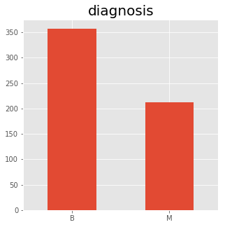

```python
fig = plt.figure(figsize=(5,5))
data.diagnosis.value_counts().plot(kind = 'bar', rot = 360)
plt.title('diagnosis',fontsize=20)
```

```python
# Label distribution is kind of balanced (60% vs 40%).
data.diagnosis.value_counts() / data.shape[0]
```

```
B    0.627417
M    0.372583
Name: diagnosis, dtype: float64
```

## 4.2 Independent variables - Predictors

- Explore the relationship between predictors and response variables and discover potential candidates of predictors to classify malignant and benign groups.
- Predictors (Ten real-valued features are computed for each cell nucleus)
  - radius (mean of distances from center to points on the perimeter)
  - texture (standard deviation of gray-scale values)
  - perimeter
  - area
  - smoothness (local variation in radius lengths)
  - compactness (perimeter^2 / area - 1.0)
  - concavity (severity of concave portions of the contour)
  - concave points (number of concave portions of the contour)
  - symmetry
  - fractal dimension ("coastline approximation" - 1)
- The mean, standard error and "worst" or largest (mean of the three largest values) of these features were computed for each image, resulting in 30 features.

```python
# Separate groups of features for visualizations.
radius_group = []
texture_group = []
perimeter_group = []
area_group = []
smoothness_group = []
compactness_group = []
concavity_group = []
concave_group = []
symmetry_group =[]
fractal_dimension_group = []

for each in data.columns:
    if 'radius' in each:
        radius_group.append(each)
    elif 'texture' in each:
        texture_group.append(each)
    elif 'perimeter' in each:
        perimeter_group.append(each)
    elif 'area' in each:
        area_group.append(each)
    elif 'smoothness' in each:
        smoothness_group.append(each)
    elif 'compactness' in each:
        compactness_group.append(each)
    elif 'concavity' in each:
        concavity_group.append(each)
    elif 'concave' in each:
        concave_group.append(each)
    elif 'symmetry' in each:
        symmetry_group.append(each)
    elif 'fractal_dimension' in each:
        fractal_dimension_group.append(each)
    # 'diagnosis' is the outcome variable.
    else:
        print(each)
```

```
diagnosis
```

- **From the pair-plot visualizations, I have found the following conclusions by observing the plots located in the diagonal lines:**
  - If there is a highly overlapping region between blue and red curves, it indicates that the predictor might not be a good candidate to distinguish between two groups, 'M' and 'B'. For example, 'texture_sd', 'smoothness_sd', and 'symmetry_sd'.
  - If there is a small shift difference between two peaks of two groups and thus blue and red curves share the most of the regions, it may tell that the predictor has some prediction power on the outcome variable, 'diagnosis'. For example, 'texture_mean', 'texture_worst', 'smoothness_mean', and 'smoothness_worst'.
  - If blue and red curves are highly separable to each other, then the associated predictor is a good candidate to classify two groups. For instance, 'radius_mean', 'radius_worst', 'perimeter_mean', and 'perimeter_worst'.

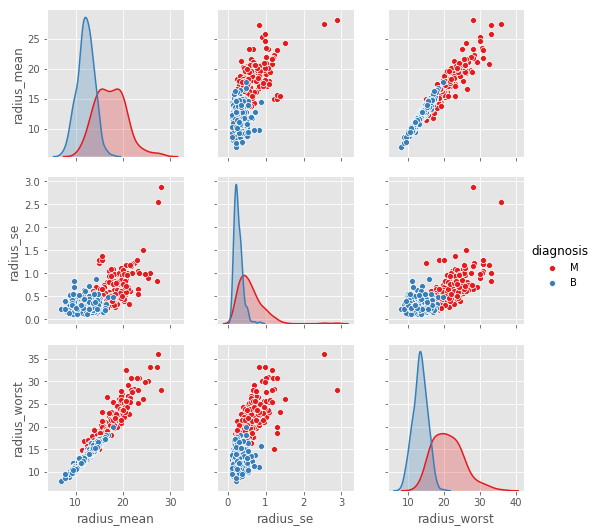

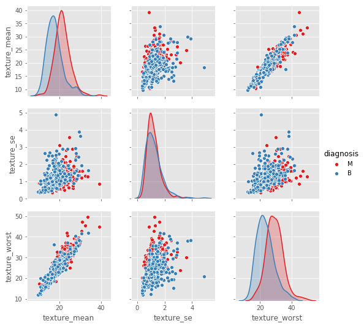

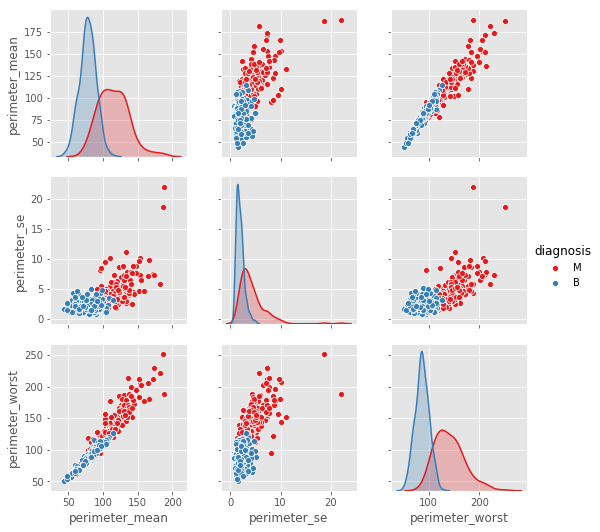

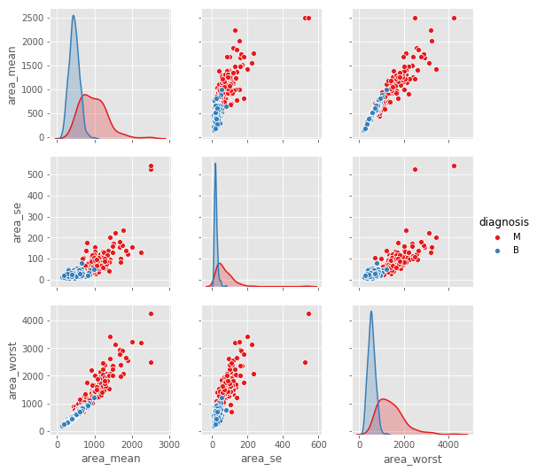

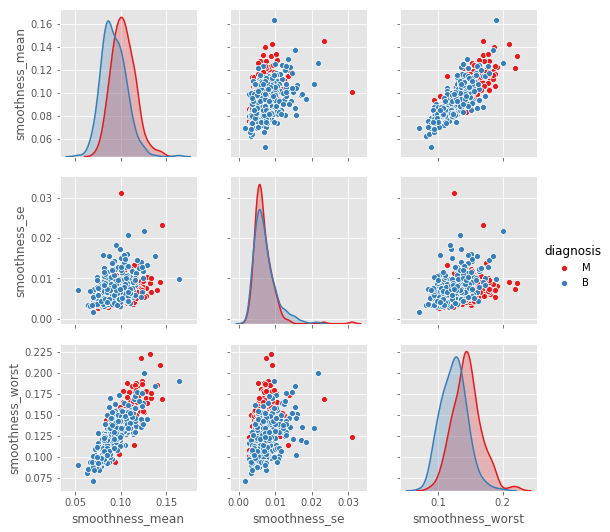

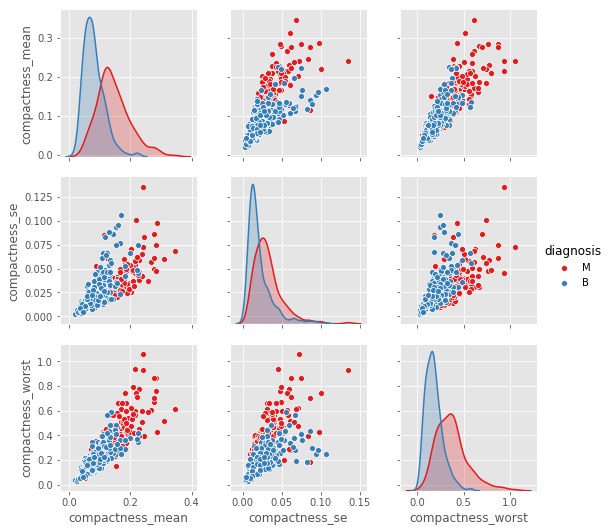

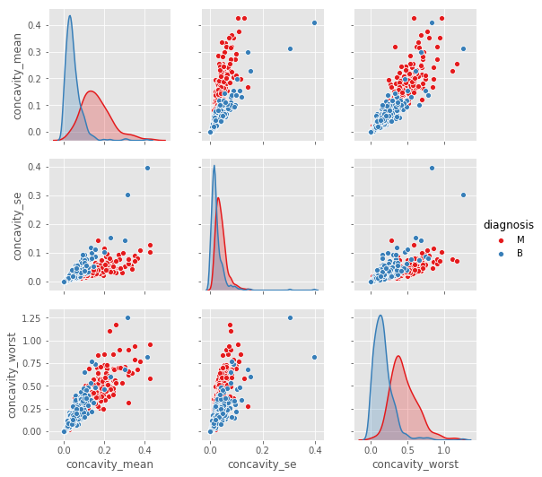

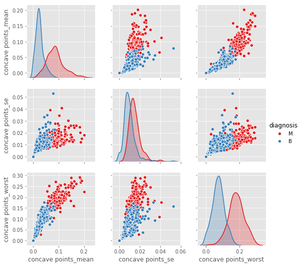

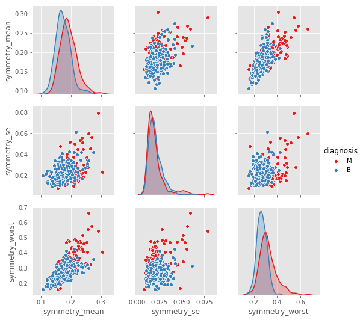

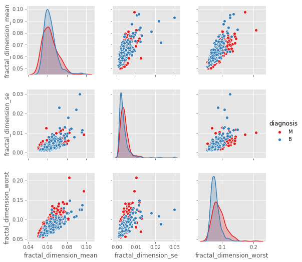

```python
group_features = [radius_group, texture_group, perimeter_group, area_group, smoothness_group,
                  compactness_group, concavity_group, concave_group, symmetry_group, fractal_dimension_group]
for each in group_features:
    relationship_pairplot(data=data, feature=each, outcome='diagnosis')
```

# 5. Next steps

- Through pair-plot visualizations, it provided me an easy and quick overview of predictors, which might be helpful in classifying diagnosis groups by observing the overlapping region between red and blue curves.
- However, it's difficult and biased to make such conclusions by naked eyes myself. Because, firstly, a high overlapping region between two curves might be draw improperly due to the scaling issue, and it's really hard to tell such overlapping could result in unfavorable classification predictions. Second, there is no quantitative way to judge which predictor is a potential candidate.
- Therefore, in the next steps, I am going to perform feature selection through statistical hypothesis testing. Then, I will compare the results attained from the testing with my initial conclusions formed here to see if there is an inconsistency conclusion.